# (Ford GoBike System Data)

## by (Diana Henry)

## Project overview

> This project has two parts that demonstrate the importance and value of data visualization techniques in the data analysis process. In the first part, I use Python visualization libraries to systematically explore a selected dataset, starting from plots of single variables and building up to plots of multiple variables. In the second part, I produce a short presentation that illustrates interesting properties, trends, and relationships that I discovered in my selected dataset. The primary method of conveying my findings was through transforming my exploratory visualizations from the first part into polished, explanatory visualizations.

## Dataset

> This data set includes information about individual rides made in a bike-sharing system covering the greater San Francisco Bay area.

### the structure of my dataset

#### it contains `183412` rows and `16` columns

#### Dataset has 16 variables consist of :

##### - Two integer varaibles (duration_sec and bike_id).

##### - Seven float variables (start_station_id, start_station_latitude, end_station_longitude, end_station_id, end_station_latitude, end_station_longitude, member_birth_year)

##### - Seven objects (start_time, end_time, start_station_name, end_station_name, user_type , member_gender, bike_share_for_all_trip)

##### - There is NAN values in 6 columns: (start_station_id, start_station_name, end_station_id, end_station_name, member_birth_year, member_gender )

## Univariate Exploration

## First: Plotting categorical variables

### Plotting gender:

### First: with absolute values:

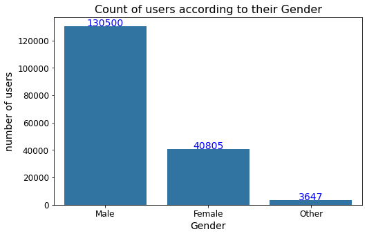

```python
# count for each gender
gender_count=bikes.member_gender.value_counts()

# resize the figure size
plt.figure(figsize=[8,5]);

# Choose the first tuple of RGB colors
base_color = sb.color_palette()[0]


sb.countplot(data=bikes, x='member_gender', color=base_color, order=gender_count.index);

# get the current tick locations and labels
locs, labels = plt.xticks(rotation=0)

# loop through each pair of locations and labels
for loc, label in zip(locs, labels):

    # get the text property for the label to get the correct count
    count = gender_count[label.get_text()]
    pct_string = '{:0}'.format(count)

    # print the annotation just below the top of the bar
    plt.text(loc, count, pct_string, ha = 'center', color = 'blue',fontsize=14)

# plot view
plt.title("Count of users according to their Gender",fontsize=16);
plt.xlabel("Gender",fontsize=14);
plt.ylabel("number of users",fontsize=14);
plt.xticks(fontsize=12);
plt.yticks(fontsize=12);
```

### Plotting gender:

### Second: with relative values:

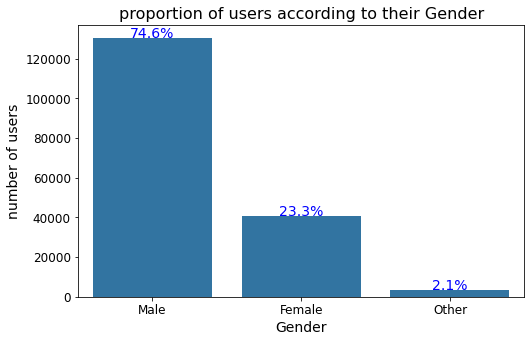

```python
# count of all observations
observations_count=len(bikes)

# resize the figure size
plt.figure(figsize=[8,5]);


plt.yticks(fontsize=12);

sb.countplot(data=bikes, x='member_gender', color=base_color, order=gender_count.index);

# get the current tick locations and labels
locs, labels = plt.xticks(rotation=0)

# loop through each pair of locations and labels
for loc, label in zip(locs, labels):

    # get the text property for the label to get the correct count
    count = gender_count[label.get_text()]
    pct_string = '{:0.1f}%'.format(100*count/observations_count)

    # print the annotation just below the top of the bar
    plt.text(loc, count, pct_string, ha = 'center', color = 'blue',fontsize=14)

# plot view
plt.title("proportion of users according to their Gender",fontsize=16);
plt.xlabel("Gender",fontsize=14);
plt.ylabel("number of users",fontsize=14);
plt.xticks(fontsize=12);
```

##### We can figure out that the proportion of males is around `75%` of all observations

### Plotting user_type:

### First: with real absolute values:

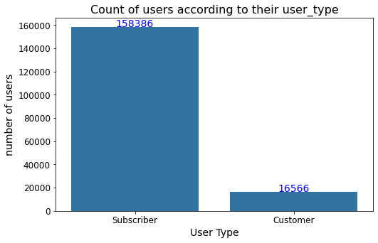

```python
# count for each user_type
userType_count=bikes.user_type.value_counts()

# resize the figure size
plt.figure(figsize=[8,5]);



sb.countplot(data=bikes, x='user_type', color=base_color, order=userType_count.index);

# get the current tick locations and labels
locs, labels = plt.xticks(rotation=0)

# loop through each pair of locations and labels
for loc, label in zip(locs, labels):

    # get the text property for the label to get the correct count
    count = userType_count[label.get_text()]
    pct_string = '{:0}'.format(count)

    # print the annotation just below the top of the bar
    plt.text(loc, count, pct_string, ha = 'center', color = 'blue',fontsize=14)

    # plot view
plt.title("Count of users according to their user_type",fontsize=16);
plt.xlabel("User Type",fontsize=14);
plt.ylabel("number of users",fontsize=14);
plt.xticks(fontsize=12);
plt.yticks(fontsize=12);
```

### Plotting User Type:

### Second: with relative values:

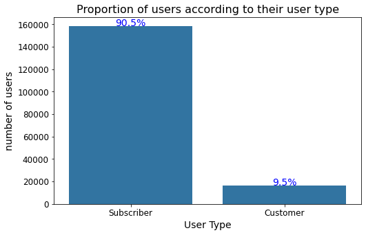

```python
# resize the figure size
plt.figure(figsize=[8,5]);

sb.countplot(data=bikes, x='user_type', color=base_color, order=userType_count.index);

# get the current tick locations and labels
locs, labels = plt.xticks(rotation=0)

# loop through each pair of locations and labels
for loc, label in zip(locs, labels):

    # get the text property for the label to get the correct count
    count = userType_count[label.get_text()]
    pct_string = '{:0.1f}%'.format(100*count/observations_count)

    # print the annotation just below the top of the bar
    plt.text(loc, count, pct_string, ha = 'center', color = 'blue',fontsize=14)


# plot view
plt.title("Proportion of users according to their user type",fontsize=16);
plt.xlabel("User Type",fontsize=14);
plt.ylabel("number of users",fontsize=14);
plt.xticks(fontsize=12);
plt.yticks(fontsize=12);
```

##### We can figure out that `90.5%` of all users are subscribers

### Second: plotting numeric variables

### Plotting Age

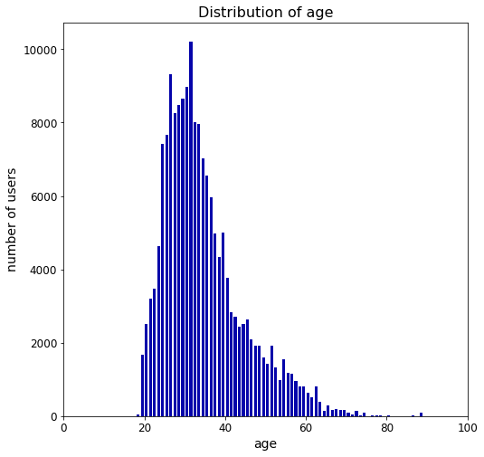

```python
# resize the figure size
plt.figure(figsize=[8,8]);
bins = np.arange(0, bikes['age'].max()+1,1)
plt.hist(data = bikes, x = 'age', bins = bins,rwidth = 0.7, color='#0504aa');
plt.xlim(0, 100,10);
plt.title("Distribution of age",fontsize=16);
plt.xlabel("age",fontsize=14);
plt.ylabel("number of users",fontsize=14);
plt.xticks(fontsize=12);
plt.yticks(fontsize=12);
```

### Most of users are between `20` and `40` years old

### Plotting trip duration

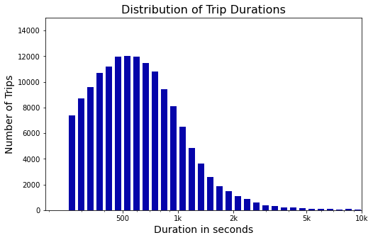

```python
log_binsize = 0.05
bins_log = 10 ** np.arange(2.4, np.log10(bikes['duration_sec'].max()) + log_binsize, log_binsize)

plt.figure(figsize=[8, 5])
plt.hist(data = bikes, x = 'duration_sec', bins = bins_log, rwidth = 0.7, color='#0504aa');
plt.title('Distribution of Trip Durations', fontsize=16);
plt.xlabel('Duration in seconds',fontsize=14);
plt.ylabel('Number of Trips',fontsize=14);
plt.xscale('log');
plt.xticks([500, 1e3, 2e3, 5e3, 1e4], [500, '1k', '2k', '5k', '10k']);
plt.axis([0, 10000, 0, 15000]);
plt.show();
```

#### Most of trips takes duration in betwwen 100 and 1000 seconds

## Bivariate Exploration

### First: `Trip Duration` and `age`:( two quatitative variables)

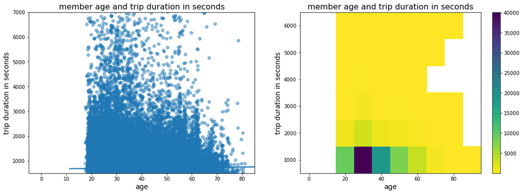

```python
plt.figure(figsize = [18, 6])
# PLOT ON LEFT
plt.subplot(1, 2, 1)
plt.title("member age and trip duration in seconds", fontsize=16)

sb.regplot(data = bikes, x = 'age', y = 'duration_sec', truncate=False, x_jitter=0.5, scatter_kws={'alpha':.5});
plt.axis([-5, 85, 500, 7000])
plt.xlabel('age',fontsize=14)
plt.ylabel('trip duration in seconds',fontsize=14)

# PLOT ON RIGHT
plt.subplot(1, 2, 2)
bins_y = np.arange(500, 7000+1, 1000)
bins_x = np.arange(-5, 100+1, 10)
# Use cmin to set a minimum bound of counts
# Use cmap to reverse the color map.
plt.title("member age and trip duration in seconds", fontsize=16)
plt.hist2d(data = bikes, x = 'age', y = 'duration_sec', cmin=0.5, cmap='viridis_r', bins = [bins_x, bins_y]);
plt.colorbar();
plt.xlabel('age',fontsize=14);
plt.ylabel('trip duration in seconds', fontsize=14);
```

> - #### We can see that most frequent users aged between 20 and 45. As remark, duration is registered by younger members

### Second `Trip Duration` and `Gender`: (a quantitative variable and a qualitative variable )

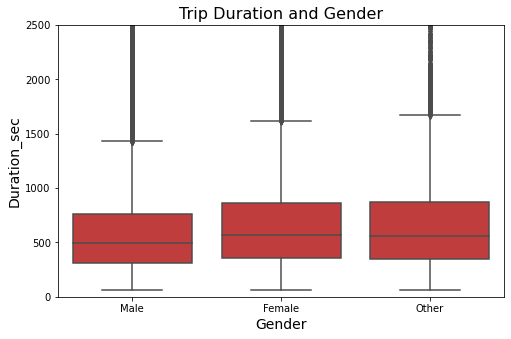

```python
plt.figure(figsize = [8, 5])
plt.title('Trip Duration and Gender', fontsize=16)
base_color = sb.color_palette()[3]
sb.boxplot(data = bikes, x = 'member_gender', y = 'duration_sec', color = base_color, order=gender_count.index)
plt.ylim([0, 2500])
plt.xlabel('Gender', fontsize=14)
plt.ylabel('Duration_sec', fontsize=14)
plt.show()
```

#### - We can notice that:

> - Max values of trip duration for females(around 1650 seconds) is longer than the value for males (around 1450 seconds)
> - `25%` of females spent around `400` seconds in their trip , but 25% of males spent around `300` seconds for their trip
> - `50%` of females spent around `600` seconds in their trip , but 50% of males spent around `500` seconds for their trip
> - `75%` of females spent around `850` seconds in their trip , but 75% of males spent around `750` seconds for their trip
> - ==> We conclude that females spend more time for their bike trip

### Third `Trip Duration` and `user_type`: (a quantitative variable and a qualitative variable )

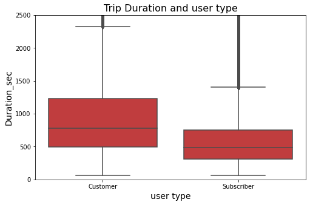

```python
plt.figure(figsize = [8, 5])
plt.title('Trip Duration and user type', fontsize=16)
base_color = sb.color_palette()[3]
sb.boxplot(data = bikes, x = 'user_type', y = 'duration_sec', color = base_color)
plt.ylim([0, 2500])
plt.xlabel('user type', fontsize=14)
plt.ylabel('Duration_sec', fontsize=14)
plt.show()
```

#### - We can notice that:

> - Customers has maximum trip duration higher than for the subscriber.
> - `25%` of customers their trip duration is less than `500` seconds, on the other hands, `25%` of subscribers spent around `250` seconds for their trip.
> - `50%` of customers spent about `750` seconds for their trip, but `50%` of subscribers spent about `500` seconds for their trip
> - `75%` of customers spent about `1300` seconds for their trip, but `75%` of subscribers spent about `750` seconds for their trip
> - ==> We conclude that customers take more time for their bike trip

## Multivariate Exploration

### First: Plotting `age`, `gender`, and `trip duration`:

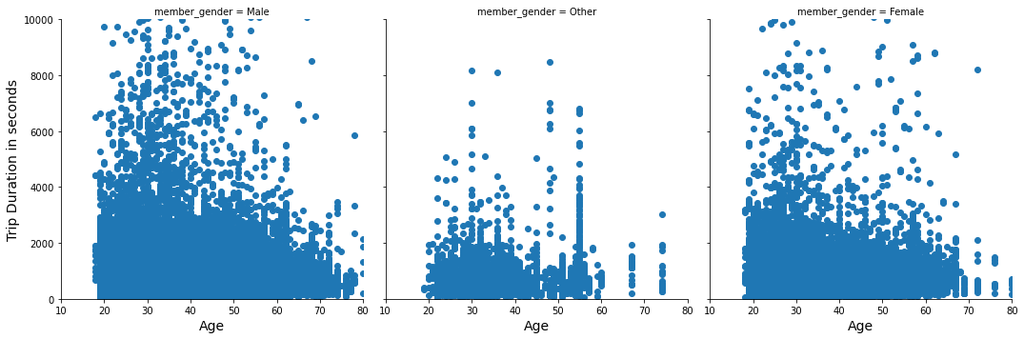

```python
gender = sb.FacetGrid(data = bikes, col = 'member_gender',xlim = [10, 80], ylim = [0, 10000],\
                      margin_titles=True,col_wrap = 3, height=5);
gender.map(plt.scatter, 'age', 'duration_sec');
gender.set_xlabels('Age',fontsize=14);
gender.set_ylabels('Trip Duration in seconds', fontsize=14);
plt.show();
```

#### We can notice that:

> - Number of `Males` is higher than number of `Females`.
> - Trip duration for both `gender` is decreasing by age.
> - For older users (age between `60` and `70`) `males` take higher trip duration than `females`.

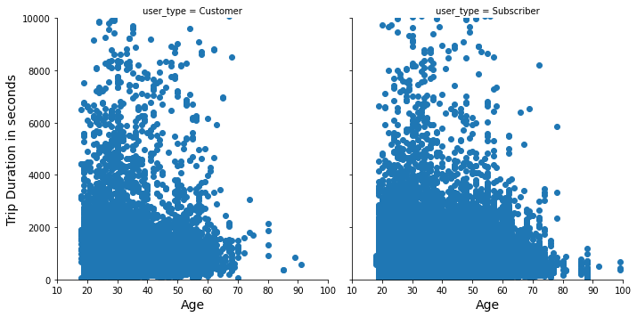

```python
User_Type = sb.FacetGrid(data = bikes, col = 'user_type',xlim = [10, 100], ylim = [0, 10000],\
                         margin_titles=True,col_wrap = 2, height=5);
User_Type.map(plt.scatter, 'age', 'duration_sec');
User_Type.set_xlabels('Age',fontsize=14);
User_Type.set_ylabels('Trip Duration in seconds', fontsize=14);
plt.show();
```